# 数据分类与预测

Audrey

## 数据分类与预测

**实验数据集：**hotel booking demand

**实验内容：**本次实验对数据集进行了多维度的分析，例如：酒店类型，推广市场，房间类型，预订时间等参数与入住率之间的关系，并且进行了可视化。最后选择了5种模型进行了预测分析。

### 1 数据载入

**加载库文件**

```r
rm(list = ls())
library(ISLR)
library(tidyverse)
```

```r
library(ggplot2)
library(e1071)
library(rpart)
library(rpart.plot)
library(randomForest)
library(pROC)
```

**加载数据**

```r
hotel_data <- read_csv("D:\\BIT\\Course\\数据挖掘\\homework\\课后作业9\\hotel_bookings.csv")
```

### 2 数据展示与分析

#### 2.1 数据展示

```r
hotel_data<- as_tibble(hotel_data)
glimpse(hotel_data)
```

```
## Rows: 119,390
## Columns: 32
## $ hotel                          <chr> "Resort Hotel", "Resort Hotel", "Res...
## $ is_canceled                    <dbl> 0, 0, 0, 0, 0, 0, 0, 0, 1, 1, 1, 0, ...
## $ lead_time                      <dbl> 342, 737, 7, 13, 14, 14, 0, 9, 85, 7...
## $ arrival_date_year              <dbl> 2015, 2015, 2015, 2015, 2015, 2015, ...
## $ arrival_date_month             <chr> "July", "July", "July", "July", "Jul...
## $ arrival_date_week_number       <dbl> 27, 27, 27, 27, 27, 27, 27, 27, 27, ...
## $ arrival_date_day_of_month      <dbl> 1, 1, 1, 1, 1, 1, 1, 1, 1, 1, 1, 1, ...
## $ stays_in_weekend_nights        <dbl> 0, 0, 0, 0, 0, 0, 0, 0, 0, 0, 0, 0, ...
## $ stays_in_week_nights           <dbl> 0, 0, 1, 1, 2, 2, 2, 2, 3, 3, 4, 4, ...
## $ adults                         <dbl> 2, 2, 1, 1, 2, 2, 2, 2, 2, 2, 2, 2, ...
## $ children                       <dbl> 0, 0, 0, 0, 0, 0, 0, 0, 0, 0, 0, 0, ...
## $ babies                         <dbl> 0, 0, 0, 0, 0, 0, 0, 0, 0, 0, 0, 0, ...
## $ meal                           <chr> "BB", "BB", "BB", "BB", "BB", "BB", ...
```

[output cut: 19 more lines]

#### 2.2 数据分析

```r
hotel_data<-hotel_data%>%
  mutate(
         hotel=as.factor(hotel),
         is_canceled=as.factor(is_canceled),
         meal=as.factor(meal),
         country=as.factor(country),
         market_segment=as.factor(market_segment),
         distribution_channel=as.factor(distribution_channel),
         is_repeated_guest=as.factor(is_repeated_guest),
         reserved_room_type=as.factor(reserved_room_type),
         assigned_room_type=as.factor(assigned_room_type),
         deposit_type=as.factor(deposit_type),
         customer_type=as.factor(customer_type),
         reservation_status=as.factor(reservation_status),
         agent=as.factor(agent),
         company=as.factor(company),
         arrival_date_day_of_month=as.factor(arrival_date_day_of_month),
         arrival_date_month=as.factor(arrival_date_month),
         arrival_date_year=as.factor(arrival_date_year)
         )
head(hotel_data)
```

| hotel | is_canceled | lead_time | arrival_date_year | arrival_date_month | arrival_date_week_number | arrival_date_day_of_month | stays_in_weekend_nights | stays_in_week_nights | adults | children | babies | meal | country | market_segment | distribution_channel | is_repeated_guest | previous_cancellations | previous_bookings_not_canceled | reserved_room_type | assigned_room_type | booking_changes | deposit_type | agent | company | days_in_waiting_list | customer_type | adr | required_car_parking_spaces | total_of_special_requests | … |
| --- | --- | --- | --- | --- | --- | --- | --- | --- | --- | --- | --- | --- | --- | --- | --- | --- | --- | --- | --- | --- | --- | --- | --- | --- | --- | --- | --- | --- | --- | --- |
| Resort Hotel | 0 | 342 | 2015 | July | 27 | 1 | 0 | 0 | 2 | 0 | 0 | BB | PRT | Direct | Direct | 0 | 0 | 0 | C | C | 3 | No Deposit | NULL | NULL | 0 | Transient | 0 | 0 | 0 | … |
| Resort Hotel | 0 | 737 | 2015 | July | 27 | 1 | 0 | 0 | 2 | 0 | 0 | BB | PRT | Direct | Direct | 0 | 0 | 0 | C | C | 4 | No Deposit | NULL | NULL | 0 | Transient | 0 | 0 | 0 | … |
| Resort Hotel | 0 | 7 | 2015 | July | 27 | 1 | 0 | 1 | 1 | 0 | 0 | BB | GBR | Direct | Direct | 0 | 0 | 0 | A | C | 0 | No Deposit | NULL | NULL | 0 | Transient | 75 | 0 | 0 | … |
| Resort Hotel | 0 | 13 | 2015 | July | 27 | 1 | 0 | 1 | 1 | 0 | 0 | BB | GBR | Corporate | Corporate | 0 | 0 | 0 | A | A | 0 | No Deposit | 304 | NULL | 0 | Transient | 75 | 0 | 0 | … |
| Resort Hotel | 0 | 14 | 2015 | July | 27 | 1 | 0 | 2 | 2 | 0 | 0 | BB | GBR | Online TA | TA/TO | 0 | 0 | 0 | A | A | 0 | No Deposit | 240 | NULL | 0 | Transient | 98 | 0 | 1 | … |
| Resort Hotel | 0 | 14 | 2015 | July | 27 | 1 | 0 | 2 | 2 | 0 | 0 | BB | GBR | Online TA | TA/TO | 0 | 0 | 0 | A | A | 0 | No Deposit | 240 | NULL | 0 | Transient | 98 | 0 | 1 | … |

```r
tail(hotel_data)
```

| hotel | is_canceled | lead_time | arrival_date_year | arrival_date_month | arrival_date_week_number | arrival_date_day_of_month | stays_in_weekend_nights | stays_in_week_nights | adults | children | babies | meal | country | market_segment | distribution_channel | is_repeated_guest | previous_cancellations | previous_bookings_not_canceled | reserved_room_type | assigned_room_type | booking_changes | deposit_type | agent | company | days_in_waiting_list | customer_type | adr | required_car_parking_spaces | total_of_special_requests | … |
| --- | --- | --- | --- | --- | --- | --- | --- | --- | --- | --- | --- | --- | --- | --- | --- | --- | --- | --- | --- | --- | --- | --- | --- | --- | --- | --- | --- | --- | --- | --- |
| City Hotel | 0 | 21 | 2017 | August | 35 | 30 | 2 | 5 | 2 | 0 | 0 | BB | BEL | Offline TA/TO | TA/TO | 0 | 0 | 0 | A | A | 0 | No Deposit | 394 | NULL | 0 | Transient | 96.14 | 0 | 2 | … |
| City Hotel | 0 | 23 | 2017 | August | 35 | 30 | 2 | 5 | 2 | 0 | 0 | BB | BEL | Offline TA/TO | TA/TO | 0 | 0 | 0 | A | A | 0 | No Deposit | 394 | NULL | 0 | Transient | 96.14 | 0 | 0 | … |
| City Hotel | 0 | 102 | 2017 | August | 35 | 31 | 2 | 5 | 3 | 0 | 0 | BB | FRA | Online TA | TA/TO | 0 | 0 | 0 | E | E | 0 | No Deposit | 9 | NULL | 0 | Transient | 225.43 | 0 | 2 | … |
| City Hotel | 0 | 34 | 2017 | August | 35 | 31 | 2 | 5 | 2 | 0 | 0 | BB | DEU | Online TA | TA/TO | 0 | 0 | 0 | D | D | 0 | No Deposit | 9 | NULL | 0 | Transient | 157.71 | 0 | 4 | … |
| City Hotel | 0 | 109 | 2017 | August | 35 | 31 | 2 | 5 | 2 | 0 | 0 | BB | GBR | Online TA | TA/TO | 0 | 0 | 0 | A | A | 0 | No Deposit | 89 | NULL | 0 | Transient | 104.40 | 0 | 0 | … |
| City Hotel | 0 | 205 | 2017 | August | 35 | 29 | 2 | 7 | 2 | 0 | 0 | HB | DEU | Online TA | TA/TO | 0 | 0 | 0 | A | A | 0 | No Deposit | 9 | NULL | 0 | Transient | 151.20 | 0 | 2 | … |

```r
summary(hotel_data)
```

```
##           hotel       is_canceled   lead_time   arrival_date_year
##  City Hotel  :79330   0:75166     Min.   :  0   2015:21996
##  Resort Hotel:40060   1:44224     1st Qu.: 18   2016:56707
##                                   Median : 69   2017:40687
##                                   Mean   :104
##                                   3rd Qu.:160
##                                   Max.   :737
##
##  arrival_date_month arrival_date_week_number arrival_date_day_of_month
##  August :13877      Min.   : 1.00            17     : 4406
##  July   :12661      1st Qu.:16.00            5      : 4317
##  May    :11791      Median :28.00            15     : 4196
##  October:11160      Mean   :27.17            25     : 4160
##  April  :11089      3rd Qu.:38.00            26     : 4147
##  June   :10939      Max.   :53.00            9      : 4096
##  (Other):47873                               (Other):94068
##  stays_in_weekend_nights stays_in_week_nights     adults
##  Min.   : 0.0000         Min.   : 0.0         Min.   : 0.000
##  1st Qu.: 0.0000         1st Qu.: 1.0         1st Qu.: 2.000
##  Median : 1.0000         Median : 2.0         Median : 2.000
##  Mean   : 0.9276         Mean   : 2.5         Mean   : 1.856
##  3rd Qu.: 2.0000         3rd Qu.: 3.0         3rd Qu.: 2.000
##  Max.   :19.0000         Max.   :50.0         Max.   :55.000
##
##     children           babies                 meal          country
##  Min.   : 0.0000   Min.   : 0.000000   BB       :92310   PRT    :48590
##  1st Qu.: 0.0000   1st Qu.: 0.000000   FB       :  798   GBR    :12129
##  Median : 0.0000   Median : 0.000000   HB       :14463   FRA    :10415
##  Mean   : 0.1039   Mean   : 0.007949   SC       :10650   ESP    : 8568
##  3rd Qu.: 0.0000   3rd Qu.: 0.000000   Undefined: 1169   DEU    : 7287
##  Max.   :10.0000   Max.   :10.000000                     ITA    : 3766
##  NA's   :4                                               (Other):28635
##        market_segment  distribution_channel is_repeated_guest
##  Online TA    :56477   Corporate: 6677      0:115580
##  Offline TA/TO:24219   Direct   :14645      1:  3810
##  Groups       :19811   GDS      :  193
##  Direct       :12606   TA/TO    :97870
##  Corporate    : 5295   Undefined:    5
##  Complementary:  743
##  (Other)      :  239
```

[output cut: 25 more lines]

```
##  Min.   :  -6.38   Min.   :0.00000             Min.   :0.0000
##  1st Qu.:  69.29   1st Qu.:0.00000             1st Qu.:0.0000
##  Median :  94.58   Median :0.00000             Median :0.0000
##  Mean   : 101.83   Mean   :0.06252             Mean   :0.5714
##  3rd Qu.: 126.00   3rd Qu.:0.00000             3rd Qu.:1.0000
##  Max.   :5400.00   Max.   :8.00000             Max.   :5.0000
##
##  reservation_status reservation_status_date
##  Canceled :43017    Min.   :2014-10-17
##  Check-Out:75166    1st Qu.:2016-02-01
##  No-Show  : 1207    Median :2016-08-07
##                     Mean   :2016-07-30
##                     3rd Qu.:2017-02-08
##                     Max.   :2017-09-14
##
```

```r
nrow(hotel_data)
```

```
## [1] 119390
```

```r
ncol(hotel_data)
```

```
## [1] 32
```

##### 2.2.1 入住信息统计

**根据国家统计入住信息**

```r
hotel_data%>%
  group_by(country)%>%
  summarise(num=n())%>%
  arrange(desc(num))
```

| country | num |
| --- | --- |
| PRT | 48590 |
| GBR | 12129 |
| FRA | 10415 |
| ESP | 8568 |
| DEU | 7287 |
| ITA | 3766 |
| IRL | 3375 |
| BEL | 2342 |
| BRA | 2224 |
| NLD | 2104 |

[output cut: 168 more lines]

**检查离群点**

```r
hotel_data%>%
  filter(adr>1000)
```

| hotel | is_canceled | lead_time | arrival_date_year | arrival_date_month | arrival_date_week_number | arrival_date_day_of_month | stays_in_weekend_nights | stays_in_week_nights | adults | children | babies | meal | country | market_segment | distribution_channel | is_repeated_guest | previous_cancellations | previous_bookings_not_canceled | reserved_room_type | assigned_room_type | booking_changes | deposit_type | agent | company | days_in_waiting_list | customer_type | adr | required_car_parking_spaces | total_of_special_requests | … |
| --- | --- | --- | --- | --- | --- | --- | --- | --- | --- | --- | --- | --- | --- | --- | --- | --- | --- | --- | --- | --- | --- | --- | --- | --- | --- | --- | --- | --- | --- | --- |
| City Hotel | 1 | 35 | 2016 | March | 13 | 25 | 0 | 1 | 2 | 0 | 0 | BB | PRT | Offline TA/TO | TA/TO | 0 | 0 | 0 | A | A | 1 | Non Refund | 12 | NULL | 0 | Transient | 5400 | 0 | 0 | … |

```r
hotel_data = hotel_data%>%
  mutate(adr = replace(adr, adr>1000, mean(adr)))
hotel_data <- hotel_data %>%
  mutate(stay_nights_total = stays_in_weekend_nights + stays_in_week_nights,
       stay_cost_total = adr * stay_nights_total)
summary(hotel_data$stay_nights_total)
```

```
##    Min. 1st Qu.  Median    Mean 3rd Qu.    Max.
##   0.000   2.000   3.000   3.428   4.000  69.000
```

```r
summary(hotel_data$stay_cost_total)
```

```
##    Min. 1st Qu.  Median    Mean 3rd Qu.    Max.
##   -63.8   146.0   267.0   357.8   446.2  7590.0
```

##### 2.2.2 数据可视化

**绘制停留天数和花费总成本散点图**

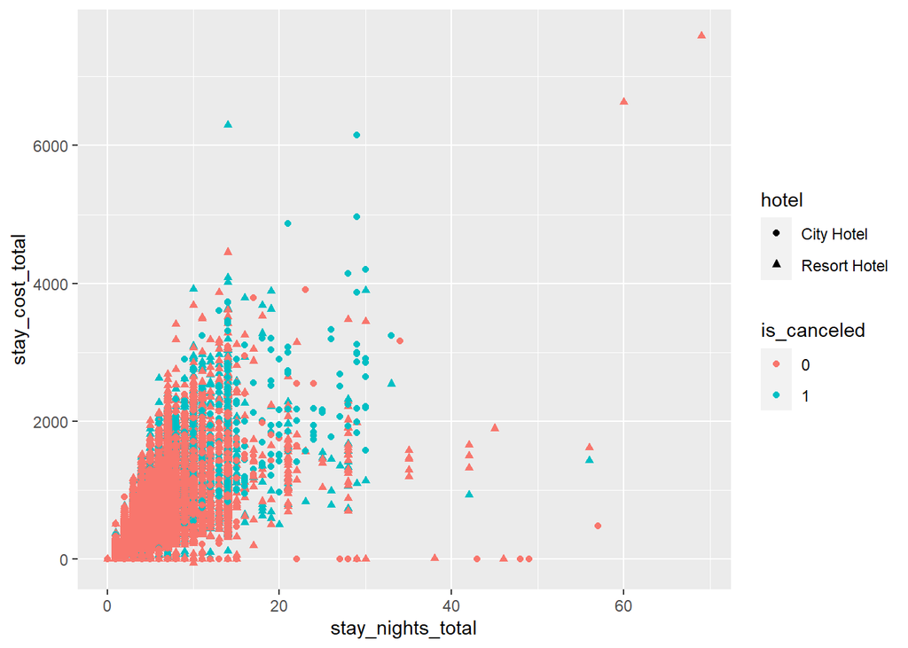

```r
ggplot(hotel_data, aes(x=stay_nights_total,y=stay_cost_total,shape=hotel,color=is_canceled))+
  geom_point(alpha=1)
```

**根据不同市场进行划分，绘制散点图**

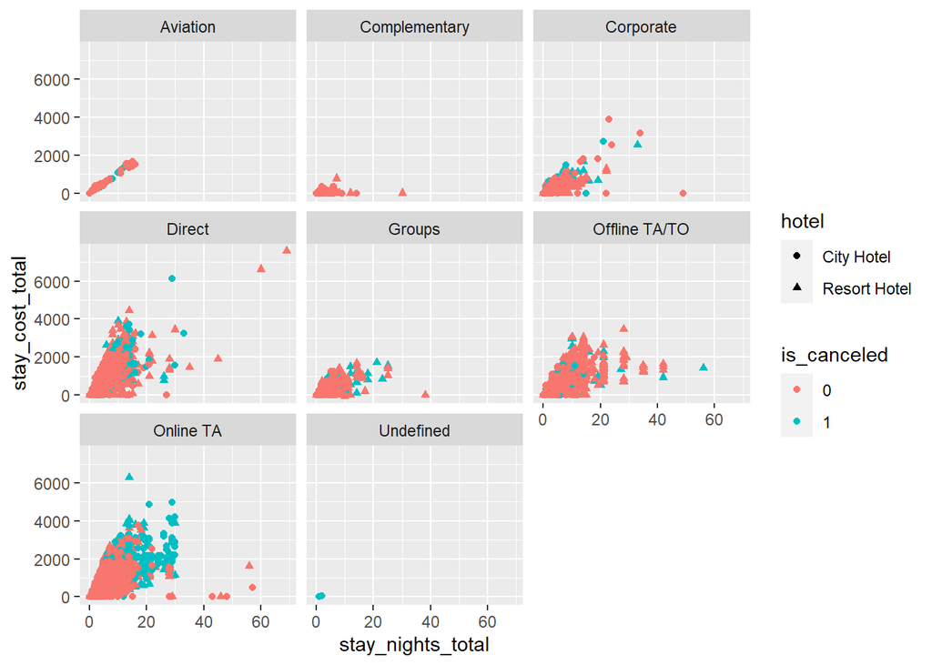

```r
ggplot(hotel_data, aes(x=stay_nights_total,y=stay_cost_total,shape=hotel,color=is_canceled))+
  geom_point()+
  facet_wrap(~market_segment)
```

**根据年份统计酒店预订数量和取消数量**

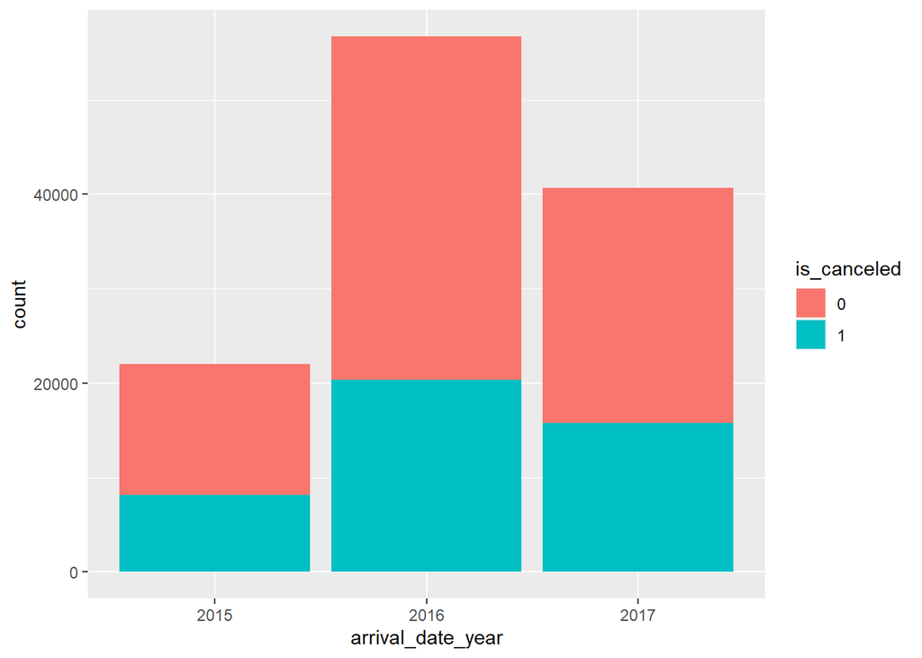

```r
hotel_data%>%
  ggplot(aes(x=arrival_date_year,fill=is_canceled))+
  geom_bar()
```

由上面直方图显示，2016年是预订和取消最多的一年。

**根据酒店类型统计预订和取消数量**

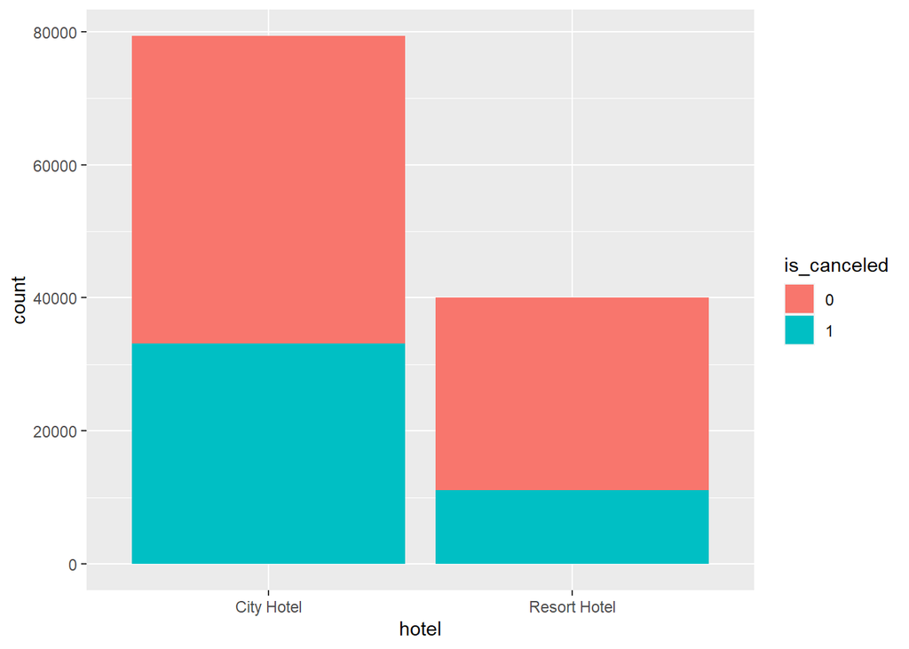

```r
hotel_data%>%
  ggplot(aes(x=hotel,fill=is_canceled))+
  geom_bar()
```

由上图可看出，城市酒店的取消数量和预定数量较多。

**根据房间类型统计预订和取消数量**

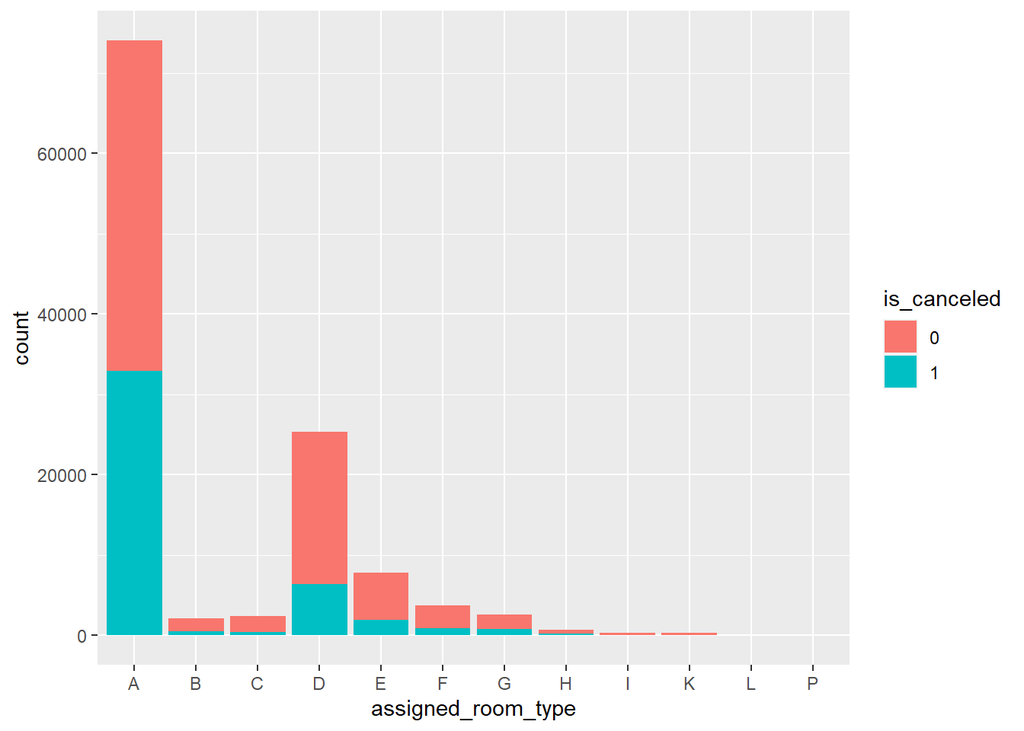

```r
hotel_data%>%
  ggplot(aes(x=assigned_room_type,fill=is_canceled))+
  geom_bar()
```

由上图可知，A类型房间预定数量和取消数量最多。

**根据分销渠道统计预订预订和取消数量**

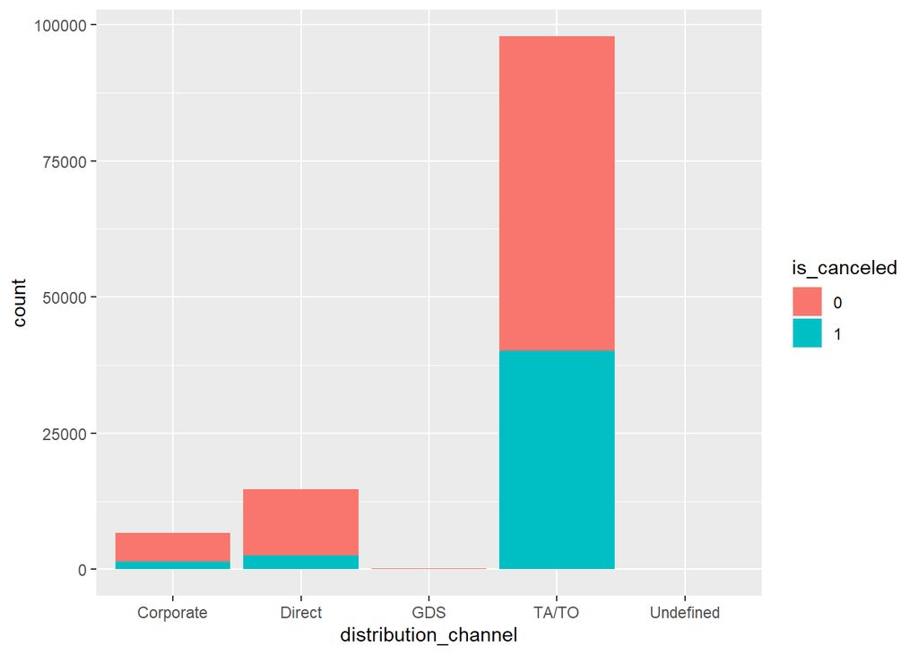

```r
hotel_data%>%
  ggplot(aes(x=distribution_channel,fill=is_canceled))+
  geom_bar()
```

由上图可知，TA/TO渠道预订和取消数量最多。

**根据等待和提前取消天数统计预订和取消数量**

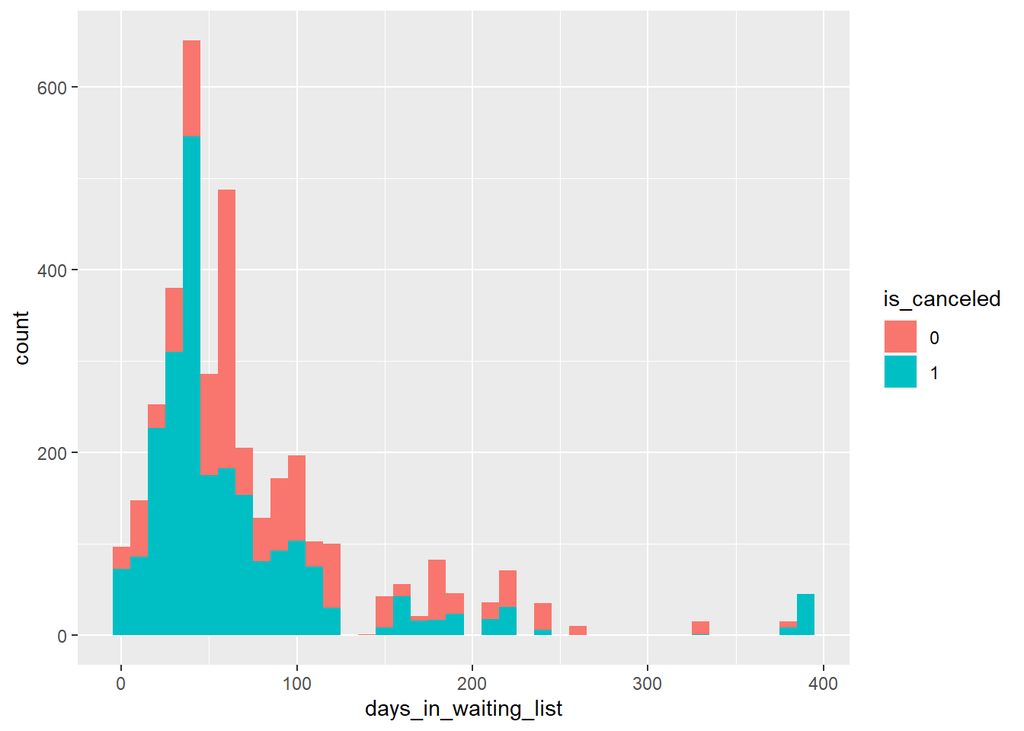

```r
hotel_data%>%
  filter(days_in_waiting_list>1)%>%
  ggplot(aes(x=days_in_waiting_list,fill=is_canceled))+
  geom_histogram(binwidth = 10)
```

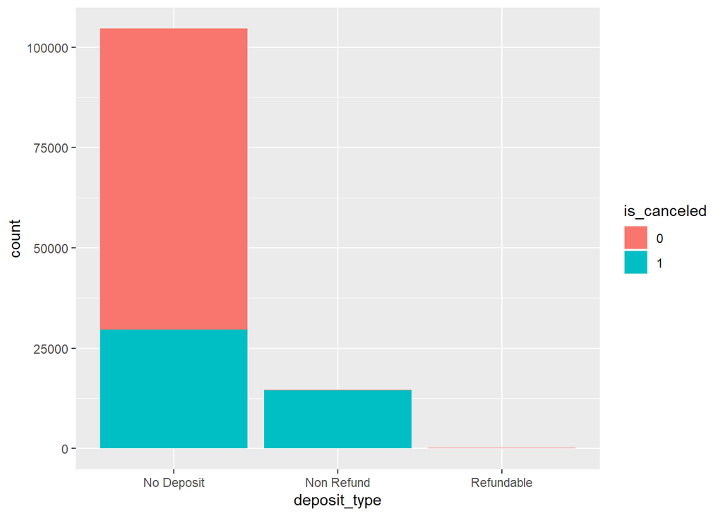

```r
hotel_data%>%
  ggplot(aes(x=deposit_type,fill=is_canceled))+
  geom_bar()
```

**根据提前预订天数统计预订和取消数量**

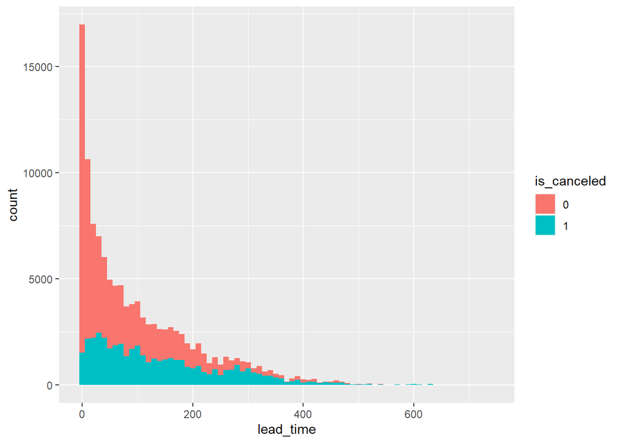

```r
hotel_data%>%
  ggplot(aes(x=lead_time,fill=is_canceled))+
  geom_histogram(binwidth=10,position="stack")
```

### 3 数据建模

#### 3.1 逻辑回归

设置随机种子为1，选用30%数据作为测试集，70%数据作为训练集。

```r
set.seed(1)
index <- sample(nrow(hotel_data), nrow(hotel_data)*0.3)
hotel_data <- hotel_data %>%
              filter(market_segment!='Undefined')
test <- hotel_data[index,]
training <-hotel_data[-index,]
training_1 <- training[c('hotel','is_canceled','lead_time','adults','children','babies','meal',
                         'market_segment','distribution_channel','is_repeated_guest',
                         'previous_cancellations','previous_bookings_not_canceled','reserved_room_type',
                         'deposit_type','days_in_waiting_list','customer_type','adr',
                         'required_car_parking_spaces','stay_nights_total','stay_cost_total')]
logit_training_model<-glm(is_canceled~.,family="binomial",data=training_1)
summary(logit_training_model)
```

```
##
## Call:
## glm(formula = is_canceled ~ ., family = "binomial", data = training_1)
##
## Deviance Residuals:
##     Min       1Q   Median       3Q      Max
## -8.4904  -0.8186  -0.4917   0.1866   5.4275
##
## Coefficients:
##                                  Estimate Std. Error z value Pr(>|z|)
## (Intercept)                    -2.562e+00  2.081e-01 -12.314  < 2e-16 ***
## hotelResort Hotel               1.303e-02  2.312e-02   0.563 0.573135
## lead_time                       3.254e-03  1.061e-04  30.655  < 2e-16 ***
## adults                          9.344e-02  1.732e-02   5.394 6.88e-08 ***
## children                        1.183e-01  2.774e-02   4.263 2.01e-05 ***
## babies                         -5.668e-01  1.101e-01  -5.148 2.63e-07 ***
## mealFB                          8.420e-01  1.240e-01   6.793 1.10e-11 ***
## mealHB                         -1.737e-01  3.143e-02  -5.529 3.22e-08 ***
## mealSC                          1.786e-01  2.981e-02   5.990 2.10e-09 ***
## mealUndefined                  -4.342e-01  1.163e-01  -3.734 0.000189 ***
## market_segmentComplementary    -2.278e-01  2.662e-01  -0.856 0.391976
## market_segmentCorporate        -3.237e-01  2.029e-01  -1.595 0.110750
## market_segmentDirect           -3.190e-01  2.254e-01  -1.415 0.157022
## market_segmentGroups           -9.763e-02  2.121e-01  -0.460 0.645291
## market_segmentOffline TA/TO    -7.649e-01  2.130e-01  -3.592 0.000329 ***
## market_segmentOnline TA         1.650e-01  2.120e-01   0.778 0.436408
## distribution_channelDirect     -4.532e-01  1.105e-01  -4.101 4.11e-05 ***
## distribution_channelGDS        -1.299e+00  3.063e-01  -4.242 2.22e-05 ***
## distribution_channelTA/TO       2.169e-02  8.230e-02   0.264 0.792105
## distribution_channelUndefined   8.842e+03  9.160e+05   0.010 0.992298
## is_repeated_guest1             -9.290e-01  9.863e-02  -9.419  < 2e-16 ***
## previous_cancellations          3.045e+00  7.371e-02  41.316  < 2e-16 ***
## previous_bookings_not_canceled -4.847e-01  2.920e-02 -16.601  < 2e-16 ***
## reserved_room_typeB             2.107e-02  8.658e-02   0.243 0.807736
## reserved_room_typeC             2.657e-01  1.039e-01   2.556 0.010578 *
## reserved_room_typeD            -4.106e-02  2.531e-02  -1.622 0.104749
## reserved_room_typeE             6.310e-02  4.097e-02   1.540 0.123519
## reserved_room_typeF            -1.983e-01  6.452e-02  -3.073 0.002119 **
## reserved_room_typeG             6.456e-02  7.704e-02   0.838 0.402025
## reserved_room_typeH             4.207e-01  1.306e-01   3.221 0.001277 **
## reserved_room_typeL             9.301e-01  9.685e-01   0.960 0.336896
## reserved_room_typeP             1.606e+01  3.104e+02   0.052 0.958741
## deposit_typeNon Refund          5.791e+00  1.362e-01  42.520  < 2e-16 ***
## deposit_typeRefundable          3.534e-01  2.347e-01   1.506 0.132141
## days_in_waiting_list            7.084e-04  5.769e-04   1.228 0.219499
## customer_typeGroup             -1.244e-01  2.054e-01  -0.606 0.544611
## customer_typeTransient          1.018e+00  6.291e-02  16.178  < 2e-16 ***
## customer_typeTransient-Party    5.008e-01  6.710e-02   7.463 8.44e-14 ***
## adr                             2.537e-03  3.410e-04   7.439 1.01e-13 ***
## required_car_parking_spaces    -8.855e+03  9.160e+05  -0.010 0.992286
## stay_nights_total               1.533e-02  6.919e-03   2.216 0.026689 *
## stay_cost_total                 2.624e-04  6.310e-05   4.159 3.20e-05 ***
## ---
## Signif. codes:  0 '***' 0.001 '**' 0.01 '*' 0.05 '.' 0.1 ' ' 1
##
## (Dispersion parameter for binomial family taken to be 1)
##
##     Null deviance: 110170  on 83571  degrees of freedom
## Residual deviance:  75236  on 83530  degrees of freedom
## AIC: 75320
##
## Number of Fisher Scoring iterations: 13
```

**逻辑回归预测**

```r
test$logit_pred_prob<-predict(logit_training_model,test,type="response")
test$logit_pred_class<-ifelse(test$logit_pred_prob>0.5,"1","0")
table(test$is_canceled==test$logit_pred_class)
```

```
##
## FALSE  TRUE
##  7875 27939
```

混淆矩阵如下所示。

```r
table(test$logit_pred_class,test$is_canceled, dnn=c("predicted","actual"))
```

```
##          actual
## predicted     0     1
##         0 21650  6982
##         1   893  6289
```

```r
27939/nrow(test)
```

```
## [1] 0.7800486
```

由显示结果可知，逻辑回归的准确率约为78%。

#### 3.2 贝叶斯模型

```r
model_nb = naiveBayes(is_canceled ~ ., data = training_1)
model_nb
```

```
##
## Naive Bayes Classifier for Discrete Predictors
##
## Call:
## naiveBayes.default(x = X, y = Y, laplace = laplace)
##
## A-priori probabilities:
## Y
##         0         1
## 0.6296726 0.3703274
##
## Conditional probabilities:
##    hotel
## Y   City Hotel Resort Hotel
##   0  0.6137620    0.3862380
##   1  0.7473586    0.2526414
##
##    lead_time
## Y        [,1]      [,2]
##   0  79.76503  91.00095
##   1 144.68312 118.44407
##
##    adults
## Y       [,1]      [,2]
##   0 1.828763 0.5095713
##   1 1.902549 0.6522965
##
##    children
## Y        [,1]      [,2]
##   0 0.1026547 0.3915963
##   1 0.1067563 0.4089315
##
##    babies
## Y         [,1]       [,2]
##   0 0.01090778 0.11952255
##   1 0.00371579 0.06137367
##
##    meal
## Y            BB          FB          HB          SC   Undefined
##   0 0.768390248 0.004199685 0.126750660 0.089143530 0.011515877
```

[output cut: 59 more lines]

```
##
##    required_car_parking_spaces
## Y         [,1]      [,2]
##   0 0.09989928 0.3033966
##   1 0.00000000 0.0000000
##
##    stay_nights_total
## Y       [,1]     [,2]
##   0 3.392547 2.591513
##   1 3.484474 2.529123
##
##    stay_cost_total
## Y       [,1]     [,2]
##   0 344.8889 321.9985
##   1 376.8547 351.8004
```

**贝叶斯模型预测**

```r
pred_nb = predict(model_nb, as.data.frame(test))
pred_prob_nb = predict(model_nb, as.data.frame(test), type = "raw")
table(pred_nb,test$is_canceled, dnn=c("predicted","actual"))
```

```
##          actual
## predicted     0     1
##         0  2922   135
##         1 19621 13138
```

```r
(2922+13138)/nrow(test)
```

```
## [1] 0.4483904
```

根据贝叶斯模型的显示结果可知，该模型的准确率很低，只有不到45%。

#### 3.3 分类树

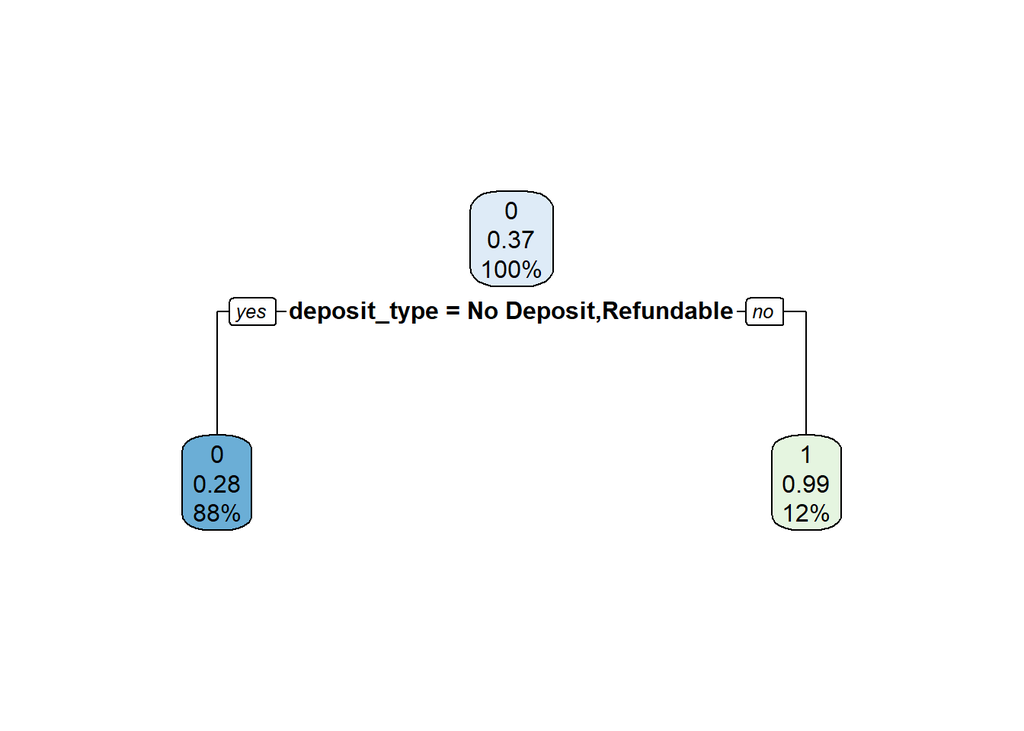

```r
training_model<-rpart(is_canceled~.,
                      data=training_1,
                      method="class",
                      control=rpart.control(cp=0.03))
rpart.plot(training_model)
```

分类树模型验证结果如下：

```r
test$ct_pred_prob<-predict(training_model,test)[,2]
test$ct_pred_class<-predict(training_model,test,type="class")
table(test$is_canceled==test$ct_pred_class)
```

```
##
## FALSE  TRUE
##  8940 26876
```

#### 3.4 决策树

**K-cross交叉验证**

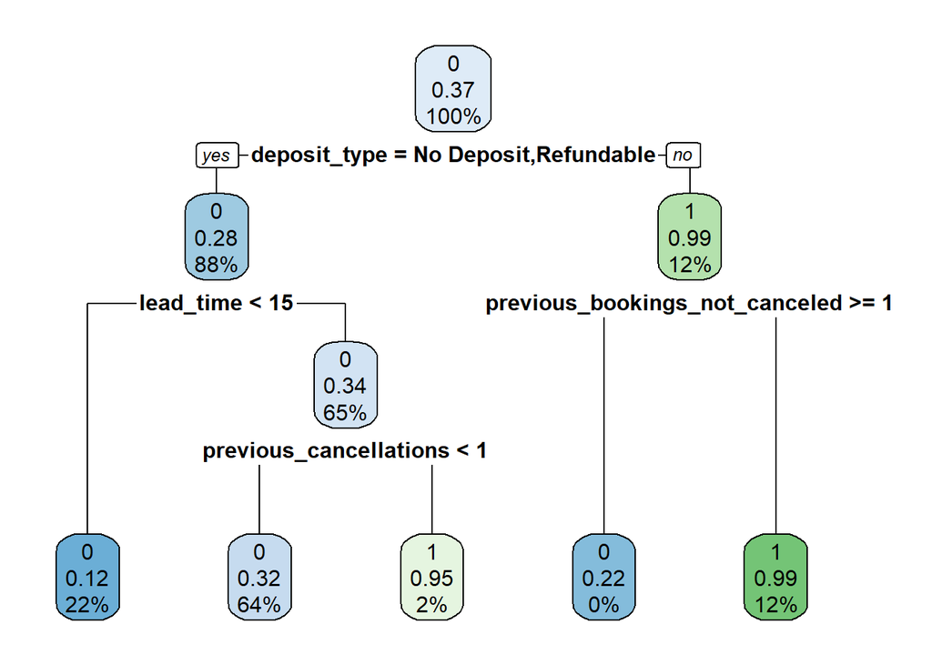

```r
set.seed(1)
full_tree<-rpart(is_canceled~.,
                     data=training_1,
                     method="class",
                     control=rpart.control(cp=0, maxdepth = 3))
rpart.plot(full_tree)
```

```r
printcp(full_tree)
```

```
##
## Classification tree:
## rpart(formula = is_canceled ~ ., data = training_1, method = "class",
##     control = rpart.control(cp = 0, maxdepth = 3))
##
## Variables actually used in tree construction:
## [1] deposit_type                   lead_time
## [3] previous_bookings_not_canceled previous_cancellations
##
## Root node error: 30949/83572 = 0.37033
##
## n= 83572
##
##           CP nsplit rel error  xerror      xstd
## 1 0.32530938      0   1.00000 1.00000 0.0045106
## 2 0.02200394      1   0.67469 0.67469 0.0040439
## 3 0.00016156      3   0.63068 0.65608 0.0040060
## 4 0.00000000      4   0.63052 0.65582 0.0040055
```

使用plotcp()，可以检查交叉验证错误率如何随着模型复杂性的增加而变化。图表中，x轴是模型复杂性，y轴是x错误率(来自交叉验证)。横线代表着标准差。

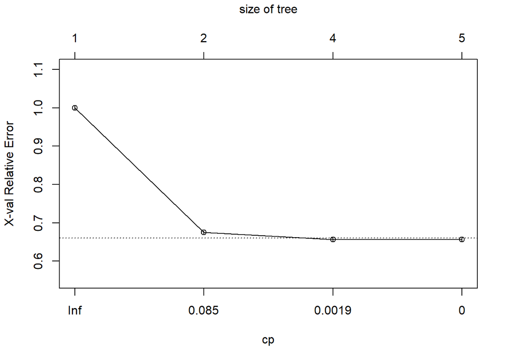

```r
plotcp(full_tree)
```

我们可以选择最小化交叉验证错误的cp值。

```r
min_xerror<-full_tree$cptable[which.min(full_tree$cptable[,"xerror"]),]
min_xerror
```

```
##          CP      nsplit   rel error      xerror        xstd
## 0.000000000 4.000000000 0.630521180 0.655820867 0.004005484
```

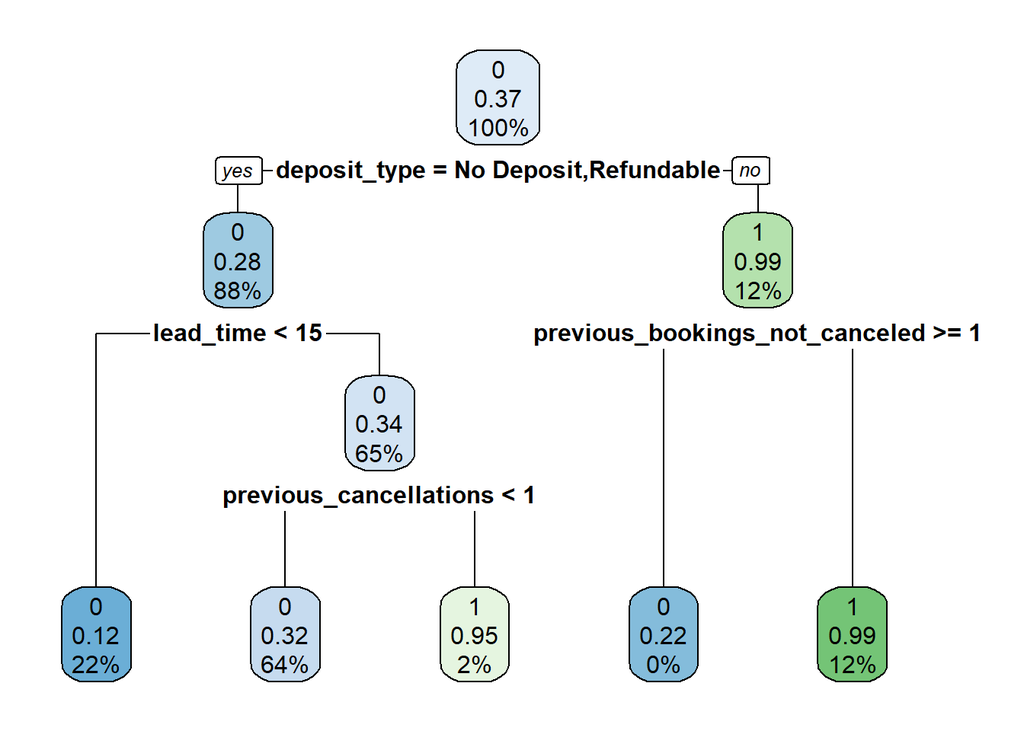

```r
# prune tree with minimum cp value
min_xerror_tree<-prune(full_tree, cp=min_xerror[1])
rpart.plot(min_xerror_tree)
```

**决策树准确率**

```r
bp_tree<-min_xerror_tree
test$ct_bp_pred_prob<-predict(bp_tree,test)[,2]
test$ct_bp_pred_class=ifelse(test$ct_bp_pred_prob>0.5,"Yes","No")
table(test$ct_bp_pred_class,test$is_canceled, dnn=c("predicted","actual"))
```

```
##          actual
## predicted     0     1
##       No  22486  8309
##       Yes    57  4964
```

```r
(22486+4964)/nrow(test)
```

```
## [1] 0.7663958
```

由上面结果可知，决策树的准确率为76.6%。

#### 3.5 随机森林

```r
set.seed(1)
rf_training_model<-randomForest(is_canceled~.,
                       data=training_1,
                       ntree=500,
                       cutoff=c(0.5,0.5),
                       mtry=2,
                       importance=TRUE)
rf_training_model
```

```
##
## Call:
##  randomForest(formula = is_canceled ~ ., data = training_1, ntree = 500,      cutoff = c(0.5, 0.5), mtry = 2, importance = TRUE)
##                Type of random forest: classification
##                      Number of trees: 500
## No. of variables tried at each split: 2
##
##         OOB estimate of  error rate: 21.79%
## Confusion matrix:
##       0     1 class.error
## 0 51977   646   0.0122760
## 1 17565 13384   0.5675466
```

**模型优化**

```r
set.seed(1)
res <- tuneRF(x = training_1%>%select(-is_canceled),
              y = training_1$is_canceled,mtryStart=2,
              ntreeTry = 500)
```

```
## mtry = 2  OOB error = 21.71%
## Searching left ...
## mtry = 1     OOB error = 25.13%
## -0.1574625 0.05
## Searching right ...
## mtry = 4     OOB error = 18.42%
## 0.1513448 0.05
## mtry = 8     OOB error = 17.36%
## 0.05779971 0.05
## mtry = 16    OOB error = 17.65%
## -0.01695616 0.05
```

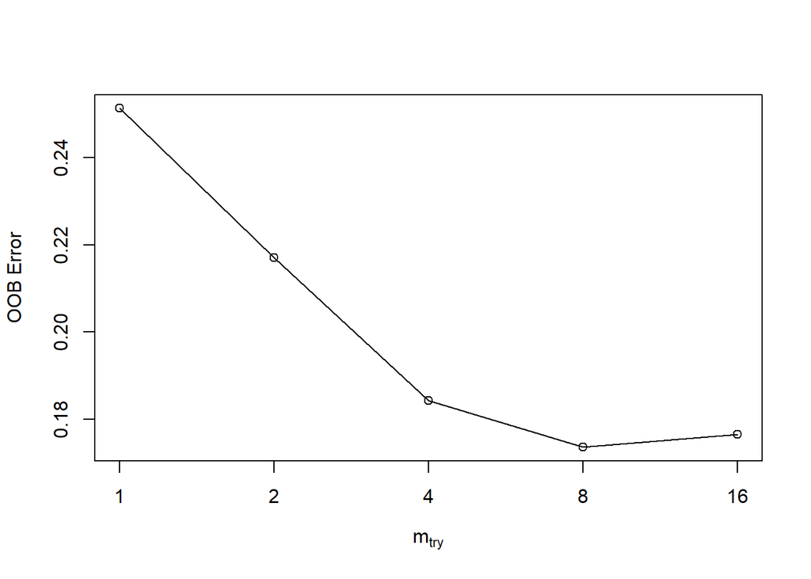

由结果可知，当metry=8时，模型显示除了最小的超出边界。

**随机森林预测**

```r
rf_best_model<-randomForest(is_canceled~.,
                       data=training_1,
                       ntree=500,
                       cutoff=c(0.5,0.5),
                       mtry=8,
                       importance=TRUE)
rf_best_model
```

```
##
## Call:
##  randomForest(formula = is_canceled ~ ., data = training_1, ntree = 500,      cutoff = c(0.5, 0.5), mtry = 8, importance = TRUE)
##                Type of random forest: classification
##                      Number of trees: 500
## No. of variables tried at each split: 8
##
##         OOB estimate of  error rate: 17.34%
## Confusion matrix:
##       0     1 class.error
## 0 46760  5863   0.1114152
## 1  8632 22317   0.2789105
```

```r
test$rf_pred_prob<-predict(rf_best_model,test,type="prob")[,2]
test$rf_pred_class<-predict(rf_best_model,test,type="class")
table(test$is_canceled==test$rf_pred_class)
```

[output not shown]

准确率如下：

```r
29451/nrow(test)
```

```
## [1] 0.8222632
```

由结果可得随机森林预测的准确率为82.22%。

#### 3.6 模型比较

绘制各种分类方法ROC曲线。

```r
ct_roc<-roc(test$is_canceled,test$ct_bp_pred_prob,auc=TRUE)
logit_roc<-roc(test$is_canceled,test$logit_pred_prob,auc=TRUE)
nb_roc = roc(test$is_canceled,pred_prob_nb[,2],auc=TRUE)
rf_roc<-roc(test$is_canceled,test$rf_pred_prob,auc=TRUE)
```

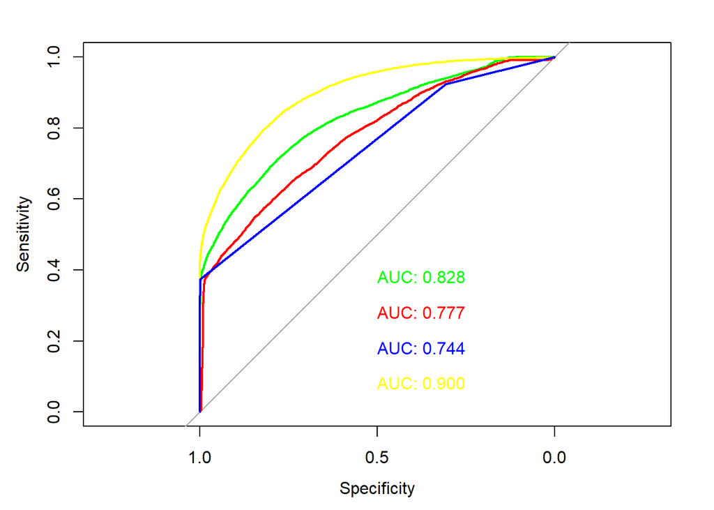

```r
plot(logit_roc,print.auc=TRUE,print.auc.y=.4, col="green")
plot(rf_roc,print.auc=TRUE,print.auc.y=.1,col="yellow",add=TRUE)
plot(nb_roc,print.auc=TRUE,print.auc.y=.3, col="red",add=TRUE)
plot(ct_roc,print.auc=TRUE,print.auc.y=.2, col="blue",add=TRUE)
```

由结果可明显看出，随机森林预测的准确率是最高的。

#### 3.7 预测结果保存

将预测的结果保存下来。

```r
final_output <- data.frame(Hotel = test$hotel, Cancellation = test$rf_pred_class)
write.csv(final_output, file = 'RF_Hotel_Solution.csv', row.names = F)
```